# Final Project Analysis

Caroline Yates

2025-05-14

# Introduction

This data set comes from Kaggle (https://www.kaggle.com/datasets/fedesoriano/body-fat-prediction-dataset). It contains observations of 15 variables from 252 men that include different body measurements. Body fat measurements can be imprecise and there has been a history of different mathematical formulas that have been used to calculate body fat.

The objective of this report is to measure the association of multiple body measurements with body fat. Through this, it may be possible to develop a tool to calculate body fat using the most appropriate body measurements to avoid time consuming processes and repeated measurements of for an individual.

# Methods

## Data Description

```r
#load packages
library(tidyverse)
library(skimr)
library(lmtest)
library(car)
#Read in data

read.csv("bodyfat.csv") -> body_data
```

## Analysis

### Exploratory Data Analysis

This data set is already in a format that is prepared for analysis, so there is minimal cleaning or data processing needed. We will begin by examining the data and performing initial data visualization.

```r
#Summary of variables
skim(body_data)
```

Data summary

| Name | body_data |
| --- | --- |
| Number of rows | 252 |
| Number of columns | 15 |
| _______________________ |  |
| Column type frequency: |  |
| numeric | 15 |
| ________________________ |  |
| Group variables | None |

**Variable type: numeric**

| skim_variable | n_missing | complete_rate | mean | sd | p0 | p25 | p50 | p75 | p100 | hist |
| --- | --- | --- | --- | --- | --- | --- | --- | --- | --- | --- |
| Density | 0 | 1 | 1.06 | 0.02 | 1.0 | 1.04 | 1.05 | 1.07 | 1.11 | ▁▅▇▆▁ |
| BodyFat | 0 | 1 | 19.15 | 8.37 | 0.0 | 12.47 | 19.20 | 25.30 | 47.50 | ▃▇▇▃▁ |
| Age | 0 | 1 | 44.88 | 12.60 | 22.0 | 35.75 | 43.00 | 54.00 | 81.00 | ▅▇▇▃▁ |
| Weight | 0 | 1 | 178.92 | 29.39 | 118.5 | 159.00 | 176.50 | 197.00 | 363.15 | ▆▇▂▁▁ |
| Height | 0 | 1 | 70.15 | 3.66 | 29.5 | 68.25 | 70.00 | 72.25 | 77.75 | ▁▁▁▂▇ |
| Neck | 0 | 1 | 37.99 | 2.43 | 31.1 | 36.40 | 38.00 | 39.42 | 51.20 | ▂▇▃▁▁ |
| Chest | 0 | 1 | 100.82 | 8.43 | 79.3 | 94.35 | 99.65 | 105.38 | 136.20 | ▂▇▅▁▁ |
| Abdomen | 0 | 1 | 92.56 | 10.78 | 69.4 | 84.57 | 90.95 | 99.33 | 148.10 | ▃▇▂▁▁ |
| Hip | 0 | 1 | 99.90 | 7.16 | 85.0 | 95.50 | 99.30 | 103.53 | 147.70 | ▆▇▁▁▁ |
| Thigh | 0 | 1 | 59.41 | 5.25 | 47.2 | 56.00 | 59.00 | 62.35 | 87.30 | ▃▇▃▁▁ |
| Knee | 0 | 1 | 38.59 | 2.41 | 33.0 | 36.98 | 38.50 | 39.92 | 49.10 | ▃▇▅▁▁ |
| Ankle | 0 | 1 | 23.10 | 1.69 | 19.1 | 22.00 | 22.80 | 24.00 | 33.90 | ▃▇▁▁▁ |
| Biceps | 0 | 1 | 32.27 | 3.02 | 24.8 | 30.20 | 32.05 | 34.32 | 45.00 | ▂▇▆▁▁ |
| Forearm | 0 | 1 | 28.66 | 2.02 | 21.0 | 27.30 | 28.70 | 30.00 | 34.90 | ▁▂▇▆▁ |
| Wrist | 0 | 1 | 18.23 | 0.93 | 15.8 | 17.60 | 18.30 | 18.80 | 21.40 | ▂▆▇▂▁ |

The data in this are very complete and there are no missing values for any of the variables. The table above includes useful summary statistics including the mean, standard deviation (sd), and quartiles for each variable.

It is also important to visualize the distributions and relationships within this data:

#### Visualization of Variables:

- Density:

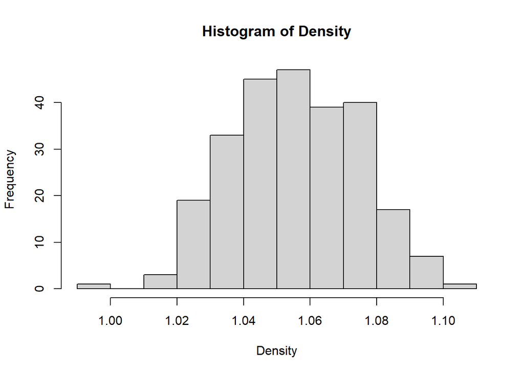

```r
hist(body_data$Density, main = "Histogram of Density", xlab = "Density")
```

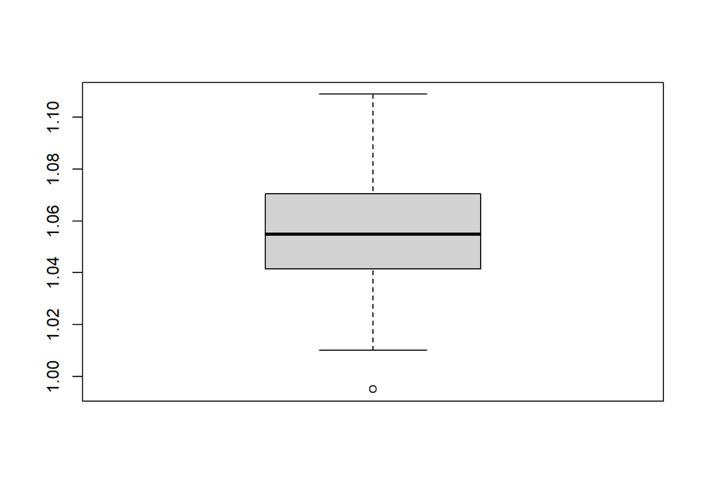

```r
boxplot(body_data$Density)
```

- Body Fat:

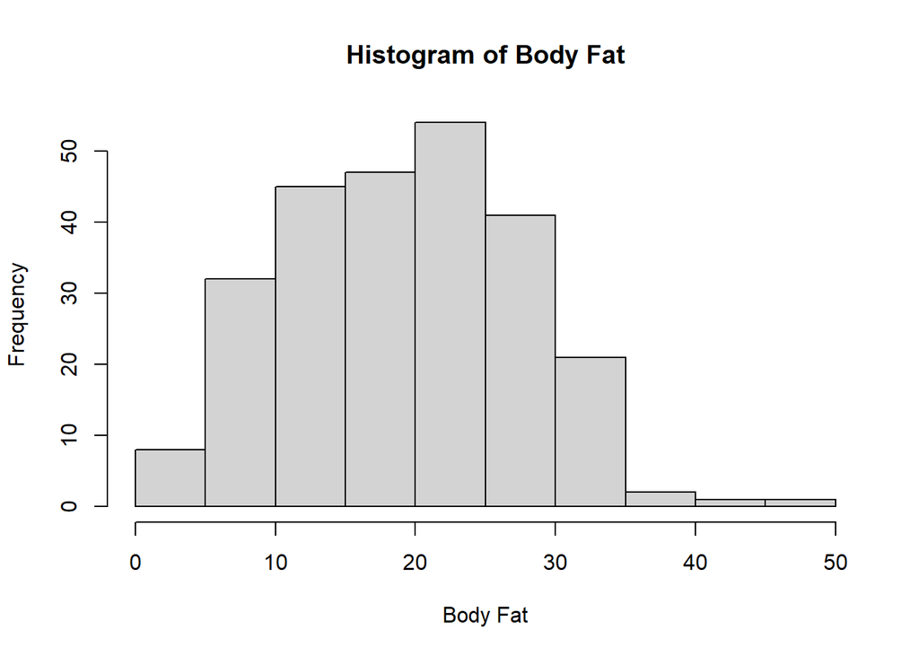

```r
hist(body_data$BodyFat, main = "Histogram of Body Fat", xlab = "Body Fat")
```

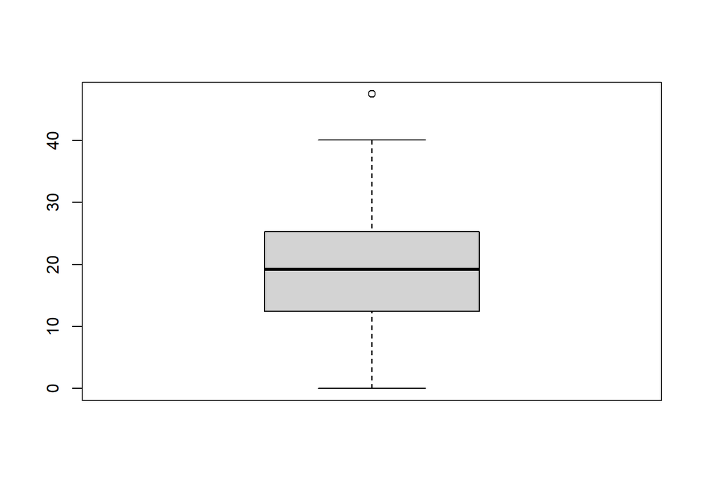

```r
boxplot(body_data$BodyFat)
```

- Age:

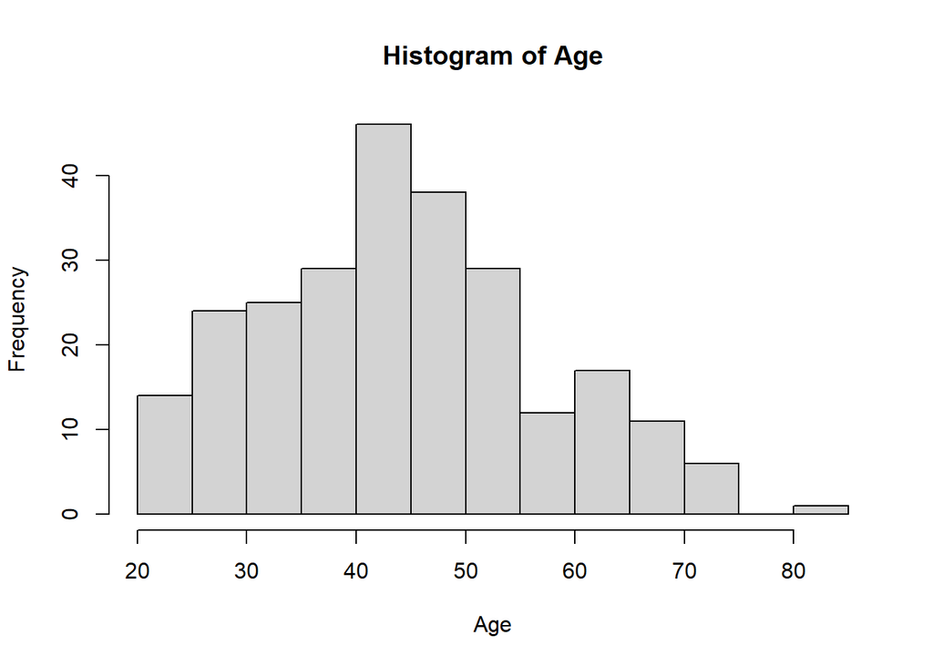

```r
hist(body_data$Age, main = "Histogram of Age", xlab = "Age")
```

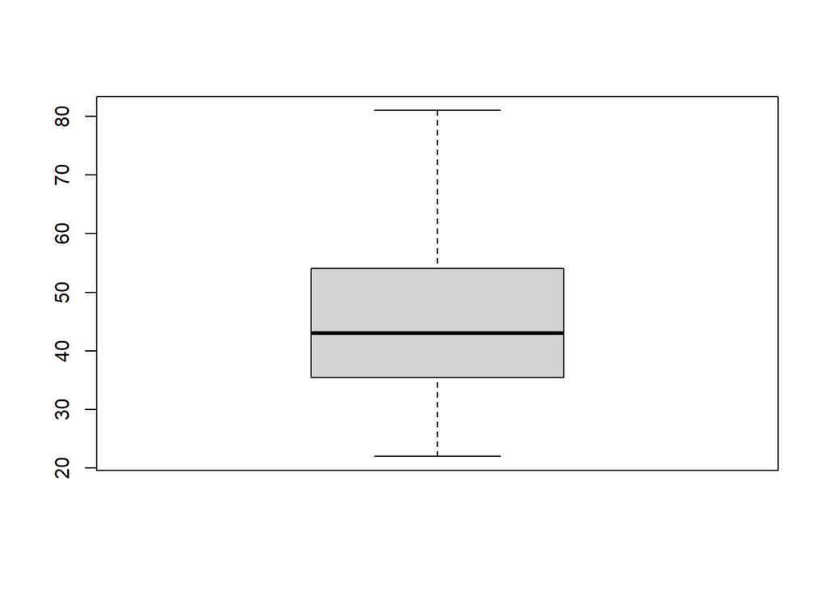

```r
boxplot(body_data$Age)
```

- Weight:

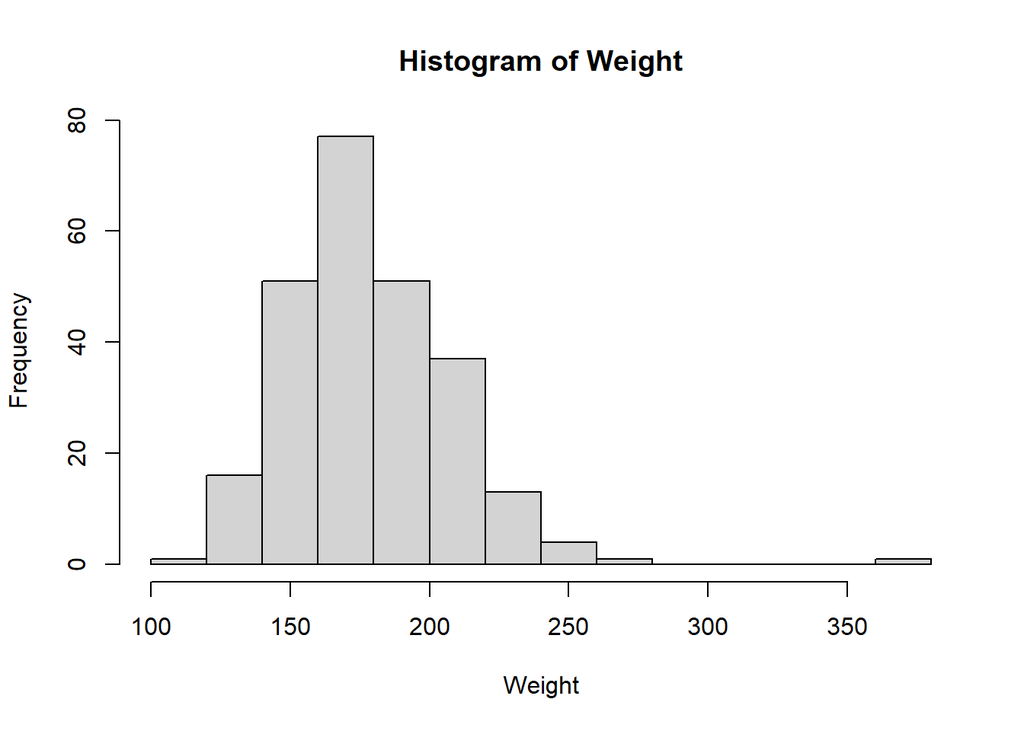

```r
hist(body_data$Weight, main = "Histogram of Weight", xlab = "Weight")
```

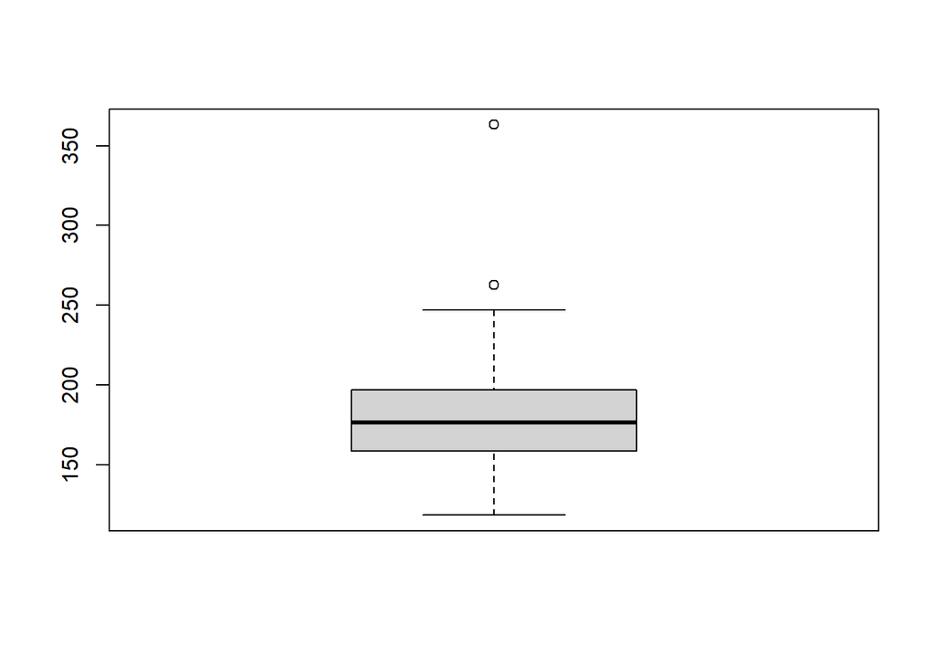

```r
boxplot(body_data$Weight)
```

- Height:

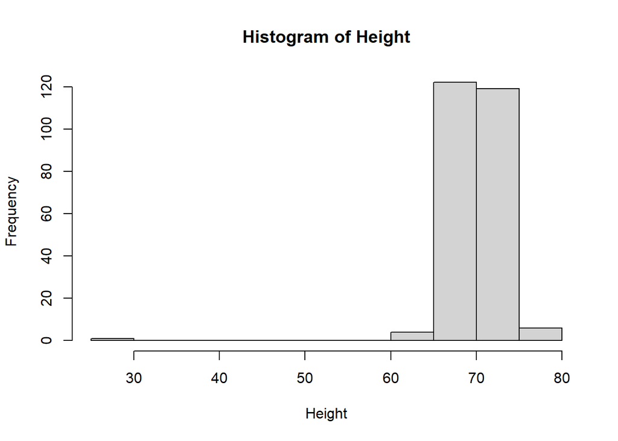

```r
hist(body_data$Height, main = "Histogram of Height", xlab = "Height")
```

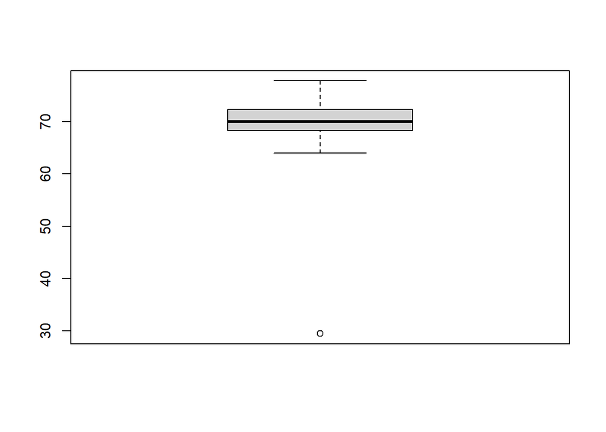

```r
boxplot(body_data$Height)
```

- Neck:

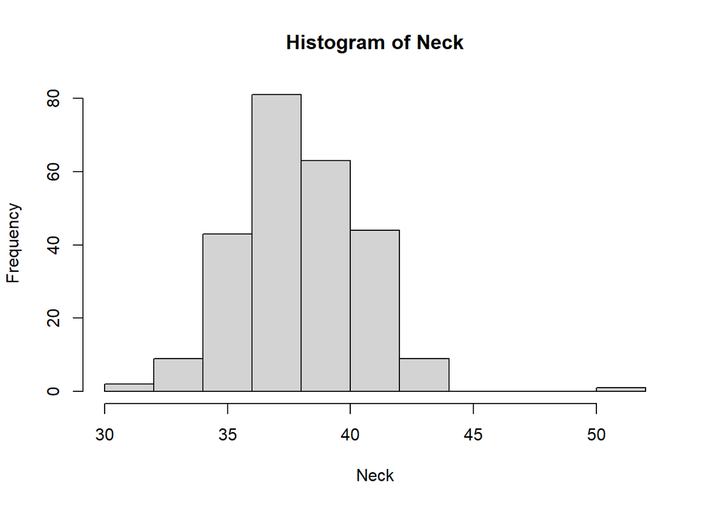

```r
hist(body_data$Neck, main = "Histogram of Neck", xlab = "Neck")
```

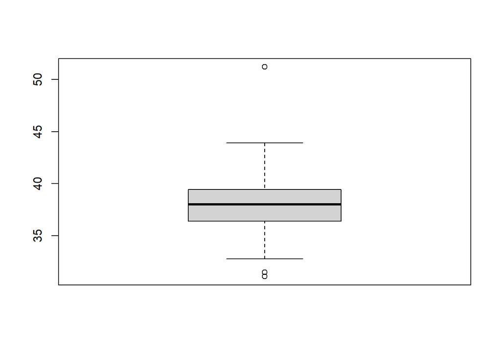

```r
boxplot(body_data$Neck)
```

- Chest:

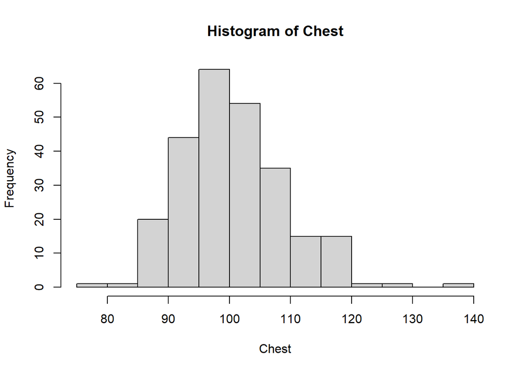

```r
hist(body_data$Chest, main = "Histogram of Chest", xlab = "Chest")
```

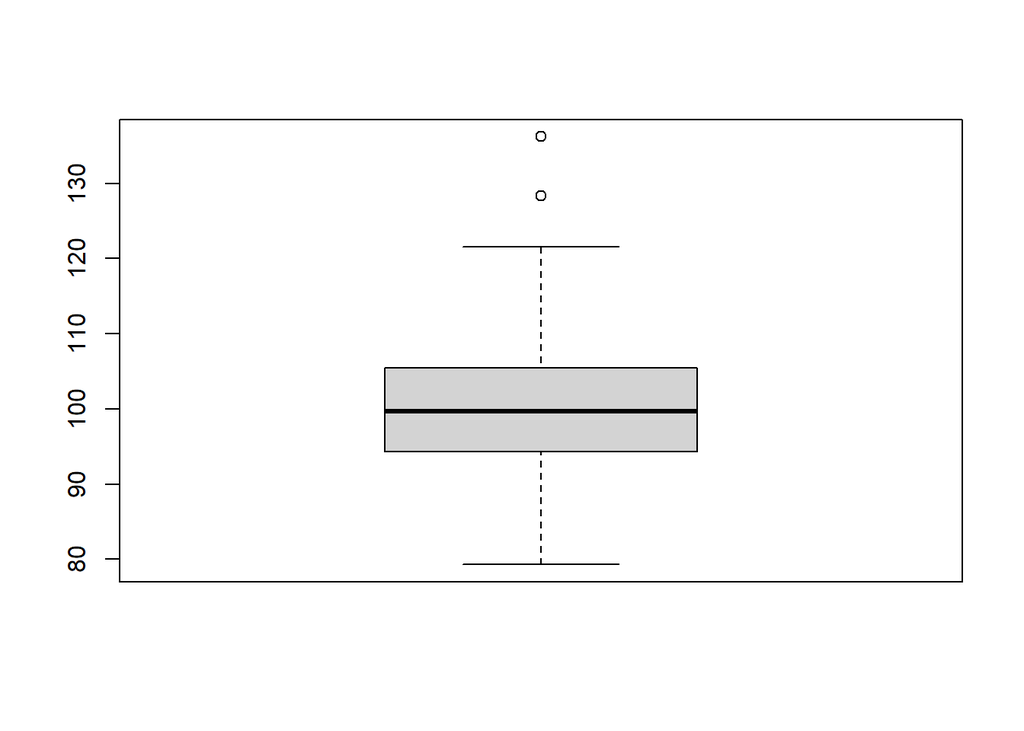

```r
boxplot(body_data$Chest)
```

- Abdomen:

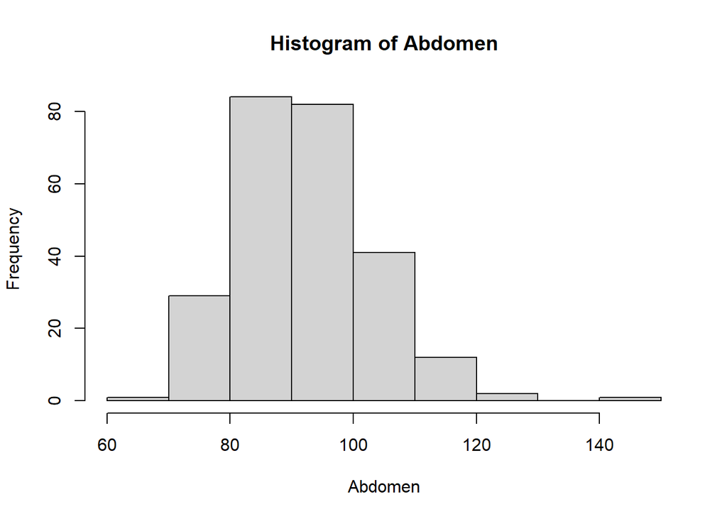

```r
hist(body_data$Abdomen, main = "Histogram of Abdomen", xlab = "Abdomen")
```

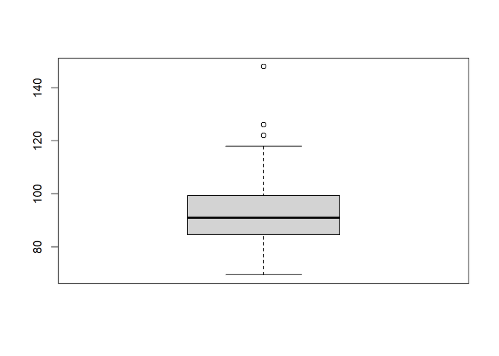

```r
boxplot(body_data$Abdomen)
```

- Hip:

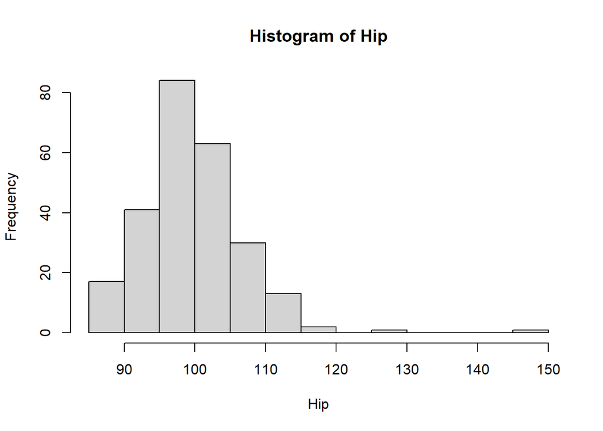

```r
hist(body_data$Hip, main = "Histogram of Hip", xlab = "Hip")
```

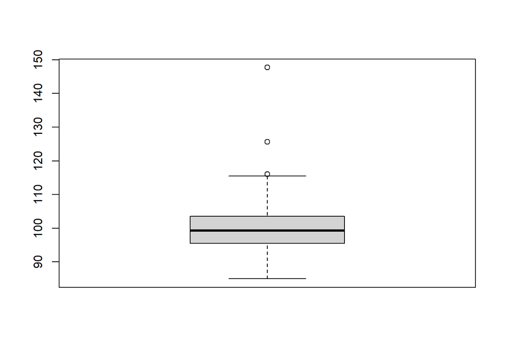

```r
boxplot(body_data$Hip)
```

- Thigh:

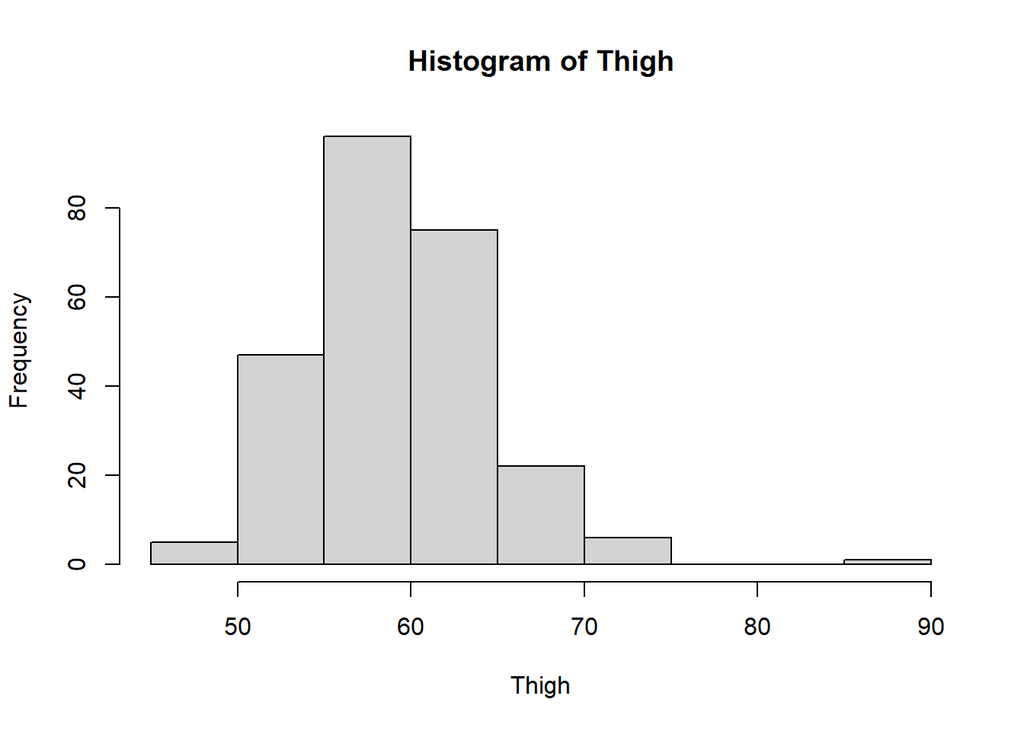

```r
hist(body_data$Thigh, main = "Histogram of Thigh", xlab = "Thigh")
```

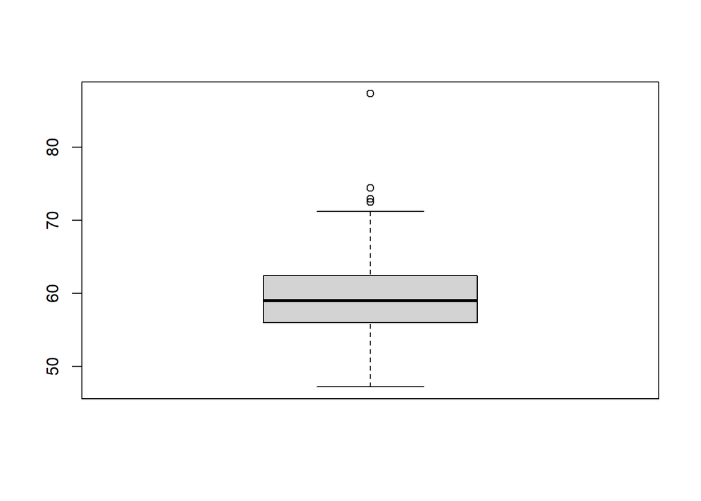

```r
boxplot(body_data$Thigh)
```

- Knee:

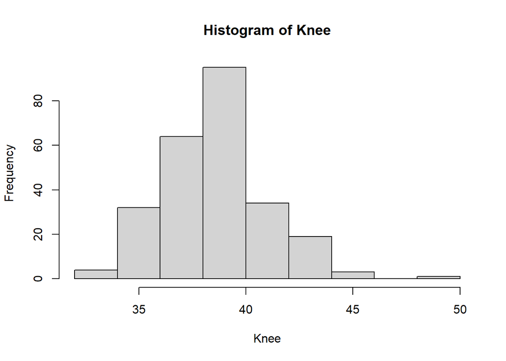

```r
hist(body_data$Knee, main = "Histogram of Knee", xlab = "Knee")
```

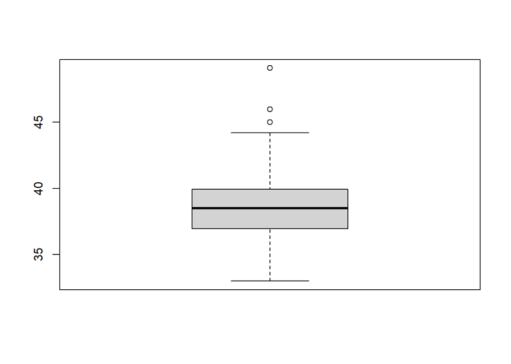

```r
boxplot(body_data$Knee)
```

- Ankle:

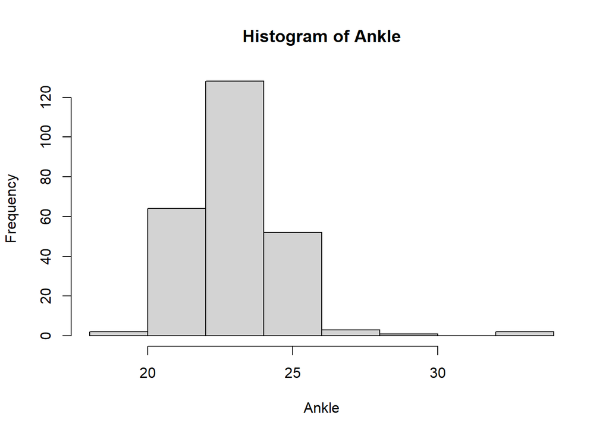

```r
hist(body_data$Ankle, main = "Histogram of Ankle", xlab = "Ankle")
```

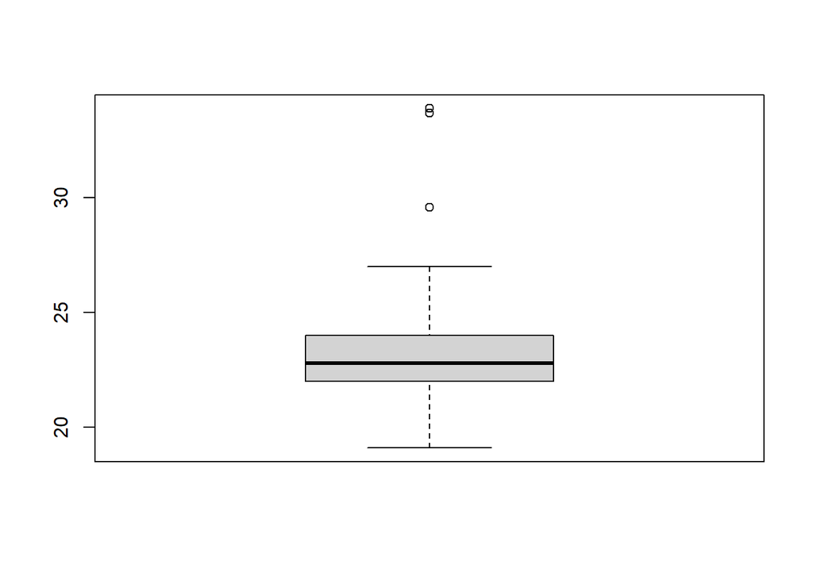

```r
boxplot(body_data$Ankle)
```

- Biceps:

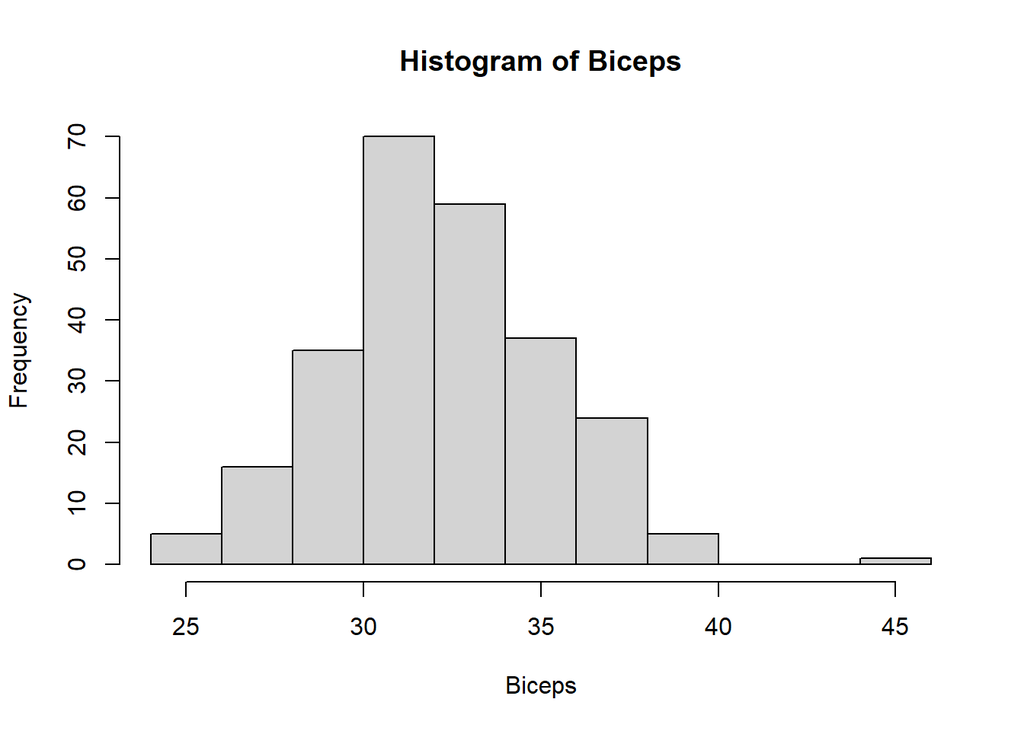

```r
hist(body_data$Biceps, main = "Histogram of Biceps", xlab = "Biceps")
```

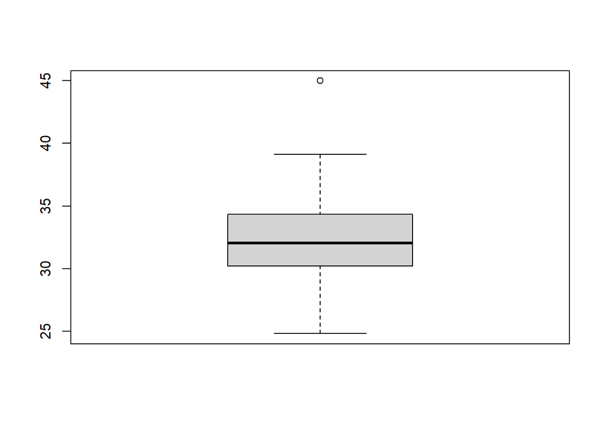

```r
boxplot(body_data$Biceps)
```

- Forearm:

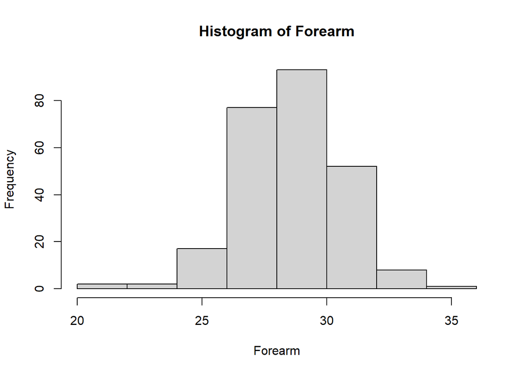

```r
hist(body_data$Forearm, main = "Histogram of Forearm", xlab = "Forearm")
```

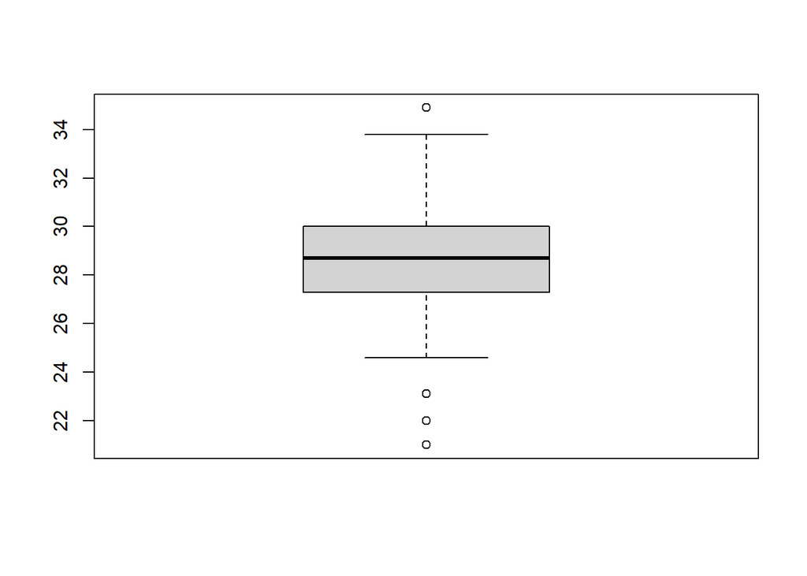

```r
boxplot(body_data$Forearm)
```

- Wrist:

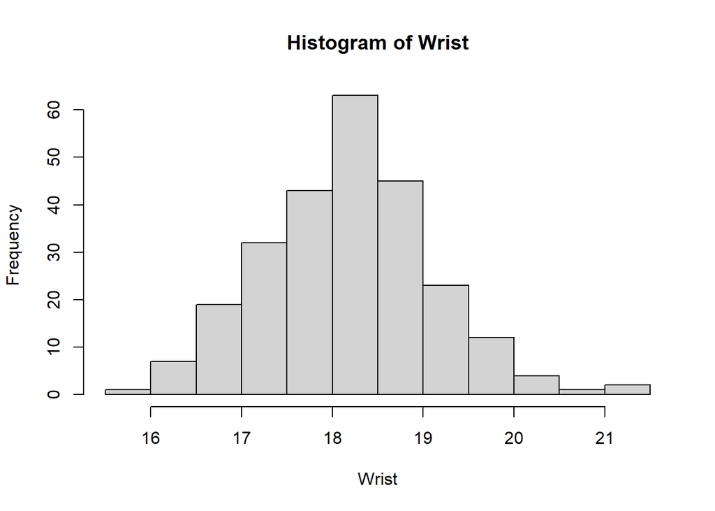

```r
hist(body_data$Wrist, main = "Histogram of Wrist", xlab = "Wrist")
```

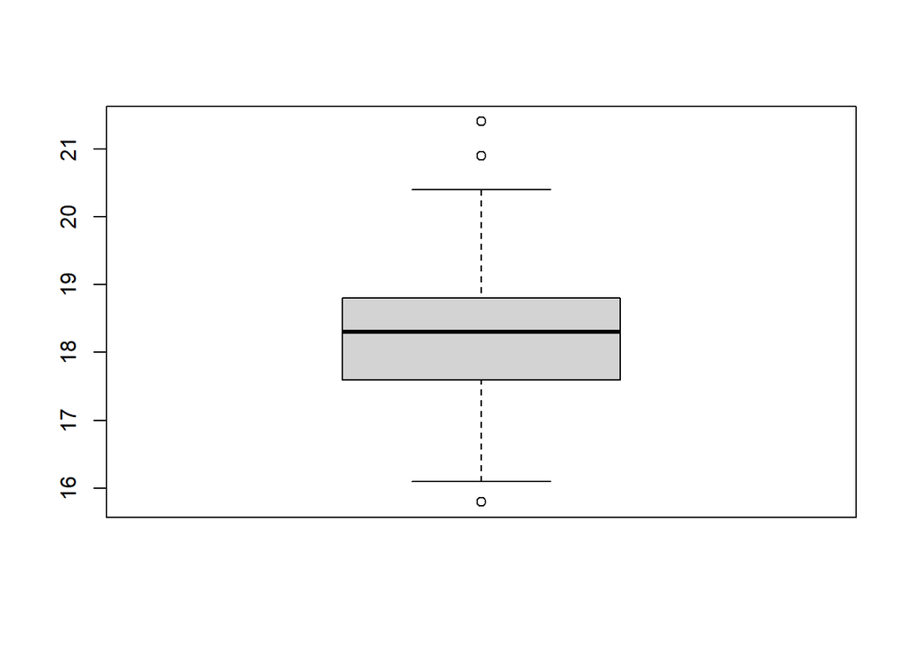

```r
boxplot(body_data$Wrist)
```

### Creating the model

```r
lm(BodyFat ~ Density + Age +Height + Weight + Abdomen + Wrist + Ankle,
   data = body_data) -> mod
summary(mod)
```

```
##
## Call:
## lm(formula = BodyFat ~ Density + Age + Height + Weight + Abdomen +
##     Wrist + Ankle, data = body_data)
##
## Residuals:
##     Min      1Q  Median      3Q     Max
## -8.3572 -0.3526 -0.1035  0.2212 15.4354
##
## Coefficients:
##               Estimate Std. Error t value Pr(>|t|)
## (Intercept)  4.492e+02  9.459e+00  47.489   <2e-16 ***
## Density     -4.099e+02  7.869e+00 -52.093   <2e-16 ***
## Age          1.401e-02  8.330e-03   1.682   0.0938 .
## Height      -8.070e-03  2.556e-02  -0.316   0.7524
## Weight       9.378e-03  9.711e-03   0.966   0.3351
## Abdomen      3.395e-02  2.742e-02   1.238   0.2169
## Wrist       -1.930e-02  1.471e-01  -0.131   0.8957
## Ankle       -8.204e-02  6.346e-02  -1.293   0.1973
## ---
## Signif. codes:  0 '***' 0.001 '**' 0.01 '*' 0.05 '.' 0.1 ' ' 1
##
## Residual standard error: 1.264 on 244 degrees of freedom
## Multiple R-squared:  0.9778, Adjusted R-squared:  0.9772
## F-statistic:  1537 on 7 and 244 DF,  p-value: < 2.2e-16
```

### Regression Assumption Verification

Now that we have a model to consider further, let’s check that the assumptions of linearity hold for our model.

1. Linear relationship:

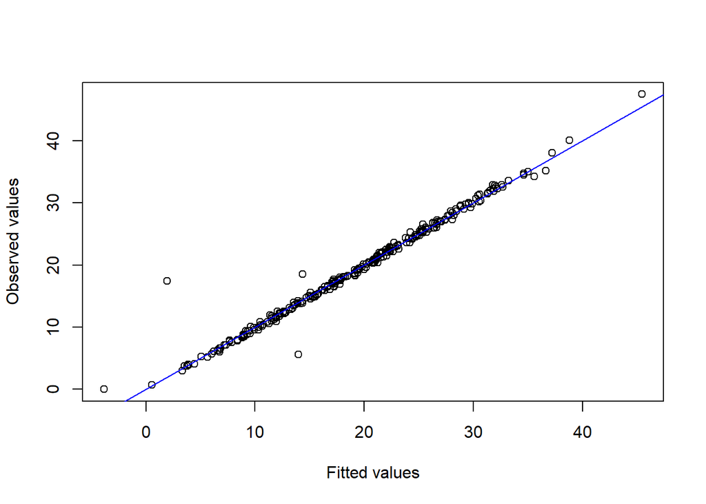

```r
plot(mod$fitted.values, body_data$BodyFat,
     xlab = "Fitted values", ylab = "Observed values")
abline(a = 0, b = 1, col = "blue")
```

The plot of the fitted values vs observed values indicates that the linearity assumption largely holds for our model. The points generally fall along the line and do not have a strong non-linear relationship.

2. Homoskedasticity:

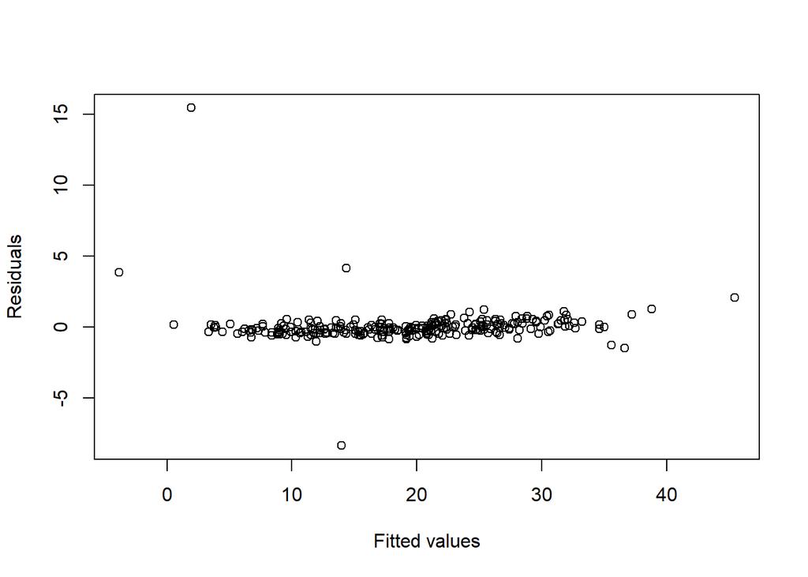

```r
plot(mod$fitted.values, mod$residuals,xlab = "Fitted values", ylab = "Residuals")
```

This visualization shows that the homoskedascity assumption could generally hold, but we can use the Beush-Pagan test to confirm this.

```r
#Breusch-Pagan Test
bp_test <- bptest(mod)
bp_test
```

```
##
##  studentized Breusch-Pagan test
##
## data:  mod
## BP = 24.318, df = 7, p-value = 0.001002
```

The Breusch-Pagan test uses the null hypothesis that there is homoskedasticity present. Since the p-value of 0.001002 is below our level of significance of 0.05, we conclude that there is heteroskedasiticity present. This means we will need to consider using robust inference with sandwhich estimators.